# Disaster Tweets Challenge

Tyler Beisel

DTSA 5511 - CU Boulder

Summer 1

## The Challenge

The goal of this kaggle competition is to determine whether a given tweet is about a real disaster or not. This is a very important task, as you would want to respond to real disasters and fake tweets very differently. This is a classic text classification problem.

We can see from the description that for each row in our data there is a location, keyword, and text field that can be used to predict the target outcome (real disaster or not).

Next, we will move on to EDA.

## Set-up and Exploratory Data Analysis (EDA)

First, we import the packages that are needed

```python
import pandas as pd
import cv2
import os
import matplotlib.pyplot as plt
from matplotlib.ticker import PercentFormatter
import tensorflow as tf
import numpy as np
import math

from tensorflow import keras
from tensorflow.keras import layers
from sklearn.model_selection import train_test_split
import tqdm

import keras.backend as K
import keras
```

Next, we load our training data into a dataframe.

```python
full_train_df = pd.read_csv("/kaggle/input/nlp-getting-started/train.csv")
full_train_df.head()
```

|  | id | keyword | location | text | target |
| --- | --- | --- | --- | --- | --- |
| 0 | 1 | NaN | NaN | Our Deeds are the Reason of this #earthquake M... | 1 |
| 1 | 4 | NaN | NaN | Forest fire near La Ronge Sask. Canada | 1 |
| 2 | 5 | NaN | NaN | All residents asked to 'shelter in place' are ... | 1 |
| 3 | 6 | NaN | NaN | 13,000 people receive #wildfires evacuation or... | 1 |
| 4 | 7 | NaN | NaN | Just got sent this photo from Ruby #Alaska as ... | 1 |

```python
full_train_df['target'].value_counts(normalize=True)
```

```
0    0.57034
1    0.42966
Name: target, dtype: float64
```

We can quickly see that our dataset is fairly balanced, with 57% of the training samples being false and 43% being true.

```python
full_train_df.shape
```

```
(7613, 5)
```

We can also see that we have 7613 samples in our training dataset. This will need to be broken into training and validation.

```python
full_train_df.info()
```

```
<class 'pandas.core.frame.DataFrame'>
RangeIndex: 7613 entries, 0 to 7612
Data columns (total 5 columns):
 #   Column    Non-Null Count  Dtype
---  ------    --------------  -----
 0   id        7613 non-null   int64
 1   keyword   7552 non-null   object
 2   location  5080 non-null   object
 3   text      7613 non-null   object
 4   target    7613 non-null   int64
dtypes: int64(2), object(3)
memory usage: 297.5+ KB
```

We can see that the location and keyword parameters are not always present. For sake of ease for this competition, we will only look at the text in the tweet, which has no missing values.

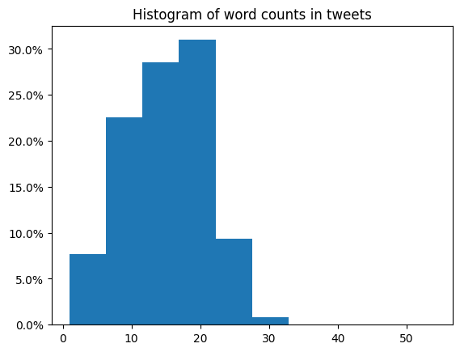

```python
word_counts = [len(x.split(' ')) for x in full_train_df['text']]

fig = plt.figure()
ax = fig.add_subplot(111)
ax.hist(word_counts, weights=np.ones_like(word_counts)*100 / len(word_counts))
ax.yaxis.set_major_formatter(PercentFormatter())
ax.set_title('Histogram of word counts in tweets')
```

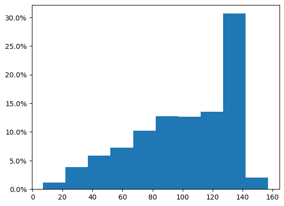

```python
char_counts = [len(x) for x in full_train_df['text']]
fig = plt.figure()
ax = fig.add_subplot(111)
ax.hist(char_counts, weights=np.ones_like(char_counts)*100 / len(char_counts))
ax.yaxis.set_major_formatter(PercentFormatter())
```

We can also see the distribution of the characters for our tweets. After all of this EDA, we are ready to begin preparing the data for training.

## Data Cleaning and Data Preparation

Next, we will clean our data and prepare it into the format needed for training. To do this, we will take the following steps:

1. Break our data into a train and validation set
2. Tokenize each tweet
3. Pad the tokenized tweets so that they all have the same length

This will give us everything we need to use this data to train recurrent neural networks

```python
train, val = train_test_split(full_train_df, test_size=0.2, random_state=4177)
```

```python
tokenizer = keras.preprocessing.text.Tokenizer(num_words=20000)
tokenizer.fit_on_texts(full_train_df['text'])

sequences = tokenizer.texts_to_sequences(train['text'])
sequences_train = keras.utils.pad_sequences(sequences,maxlen=40, padding='post')
```

```python
print(sequences_train)
print()
print(sequences_train.shape)
```

```
[[  356  1048   620 ...     0     0     0]
 [  639  1447  1450 ...     0     0     0]
 [ 1930   941   688 ...     0     0     0]
 ...
 [14562   824   192 ...     0     0     0]
 [15383    11    18 ...     0     0     0]
 [  554   278   469 ...     0     0     0]]

(6090, 40)
```

```python
sequences = tokenizer.texts_to_sequences(val['text'])
sequences_val = keras.utils.pad_sequences(sequences, maxlen=40, padding='post')
```

```python
print(sequences_val)
print()
print(sequences_val.shape)
```

```
[[  142     7   663 ...     0     0     0]
 [   64    11    18 ...     0     0     0]
 [12127  3364  1566 ...     0     0     0]
 ...
 [  376   736   737 ...     0     0     0]
 [ 8723    67     4 ...     0     0     0]
 [ 1696   258   114 ...     0     0     0]]

(1523, 40)
```

As you can see, we have tokenized our inputs so that they are all the same length. This tokenized format will also make it easy to create embeddings for each tweet.

There are also 6090 tweets in our train set and 1523 in our val set.

## Model Experimentation

For this challenge, I want to try out 3 different architectures.

1. An LSTM model
2. A GRU model
3. A simple RNN

My purpose for this challenge is to learn more about building RNNs from scratch. This is why I have chosen these 3 architectures. These 3 architectures are building blocks to understanding the state of the art solutions and how modern RNNs are built. I am sure that I could obtain better results by conducting transfer learning on a state of the art text classification model from tf.hub (like BERT), but that would not help me understand how to build these models from scratch.

Each of these models will have the following architectures

1. Embedding layer - This will take each tokenized input and create an embedding for each word of length 128
2. RNN layer - This will be either an LSTM, GRU, or simple RNN. Each will have 128 cells and dropout of 0.25
3. A Fully Connected Classifier with 2 hidden layers and a sigmoid final activation function

```python
def make_rnn(rnn_type, num_rnn_layers):
    model = keras.Sequential()
    model.add(layers.Embedding(20000,128,input_length=40))

    for i in range(num_rnn_layers):
        if rnn_type == 'LSTM':
            model.add(layers.Bidirectional(layers.LSTM(128, dropout=0.25)))
        elif rnn_type == 'GRU':
            model.add(layers.Bidirectional(layers.GRU(128, dropout=0.25)))
        else:
            model.add(layers.Bidirectional(layers.SimpleRNN(128, dropout=0.25)))
        model.add(layers.Dropout(0.25))

    model.add(layers.Dense(64, activation='relu'))
    model.add(layers.Dropout(0.25))
    model.add(layers.Dense(32, activation='relu'))
    model.add(layers.Dropout(0.25))
    model.add(layers.Dense(1, activation="sigmoid"))
    return model
```

### LSTM

We will start first with an LSTM model.

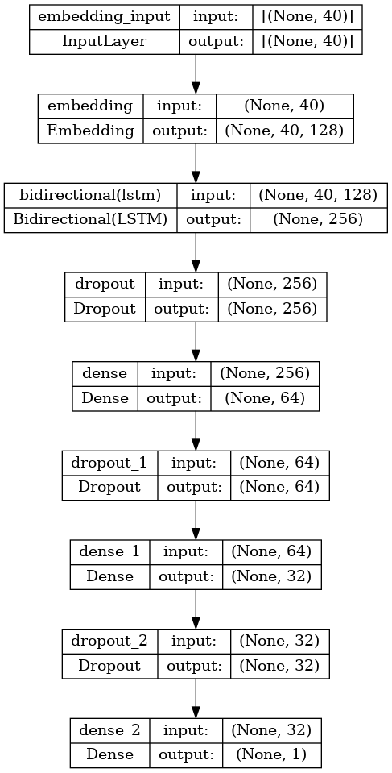

```python
model = make_rnn('LSTM', 1)
keras.utils.plot_model(model, show_shapes=True)
```

```python
model.summary()
```

```
Model: "sequential"
_________________________________________________________________
 Layer (type)                Output Shape              Param #
=================================================================
 embedding (Embedding)       (None, 40, 128)           2560000

 bidirectional (Bidirectiona  (None, 256)              263168
 l)

 dropout (Dropout)           (None, 256)               0

 dense (Dense)               (None, 64)                16448

 dropout_1 (Dropout)         (None, 64)                0

 dense_1 (Dense)             (None, 32)                2080

 dropout_2 (Dropout)         (None, 32)                0

 dense_2 (Dense)             (None, 1)                 33

=================================================================
Total params: 2,841,729
Trainable params: 2,841,729
Non-trainable params: 0
_________________________________________________________________
```

Our model has 2.8 million parameters, but 2.56 million of that comes from our embedding layer.

```python
epochs = 25

callbacks = [
    keras.callbacks.ModelCheckpoint("lstm_{epoch}.tf"),
]
model.compile(
    optimizer=keras.optimizers.Adam(),
    loss="binary_crossentropy",
    metrics=["accuracy"],
)
history_lstm = model.fit(
    x=sequences_train,
    y=train['target'],
    epochs=epochs,
    callbacks=callbacks,
    validation_data=(sequences_val, val['target']),
    batch_size=16
)
```

```python
def plot_training_results(history):
    plt.plot(history.history['accuracy'])
    plt.plot(history.history['val_accuracy'])
    plt.title('Accuracy')
    plt.ylabel('Accuracy')
    plt.xlabel('Epoch')
    plt.legend(['train', 'validation'], loc='upper left')
    plt.show()

    plt.plot(history.history['loss'])
    plt.plot(history.history['val_loss'])
    plt.title('Loss')
    plt.ylabel('Loss')
    plt.xlabel('Epoch')
    plt.legend(['train', 'validation'], loc='upper left')
    plt.show()
```

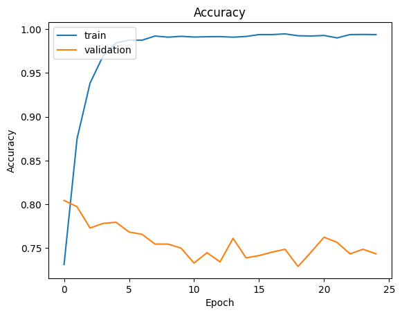

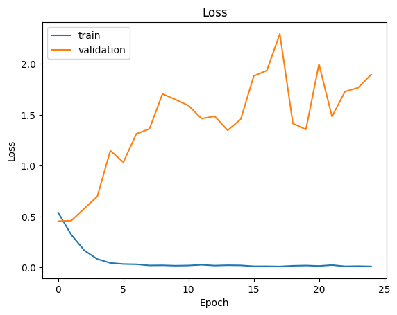

```python
plot_training_results(history_lstm)
```

```python
import gc
del model
gc.collect()
```

```
134472
```

### GRU

Next, we will look at a GRU model

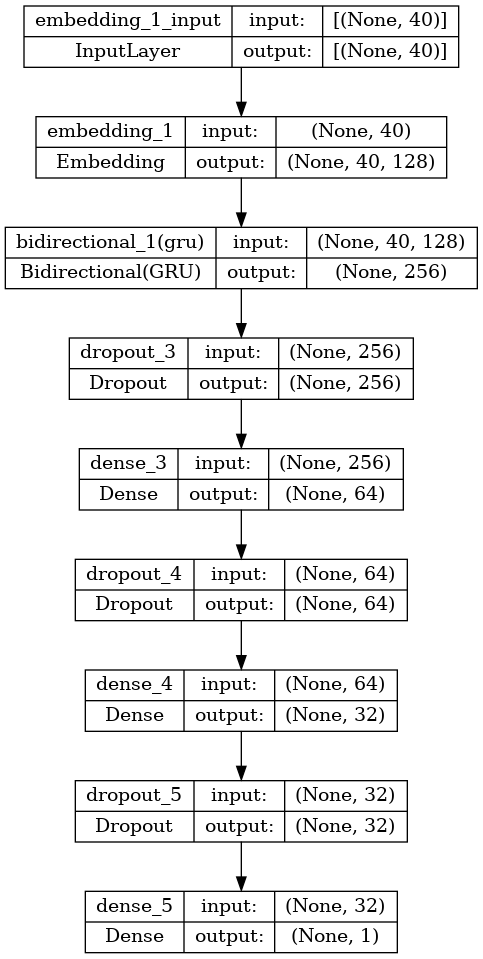

```python
model = make_rnn('GRU', 1)
keras.utils.plot_model(model, show_shapes=True)
```

```python
model.summary()
```

```
Model: "sequential_1"
_________________________________________________________________
 Layer (type)                Output Shape              Param #
=================================================================
 embedding_1 (Embedding)     (None, 40, 128)           2560000

 bidirectional_1 (Bidirectio  (None, 256)              198144
 nal)

 dropout_3 (Dropout)         (None, 256)               0

 dense_3 (Dense)             (None, 64)                16448

 dropout_4 (Dropout)         (None, 64)                0

 dense_4 (Dense)             (None, 32)                2080

 dropout_5 (Dropout)         (None, 32)                0

 dense_5 (Dense)             (None, 1)                 33

=================================================================
Total params: 2,776,705
Trainable params: 2,776,705
Non-trainable params: 0
_________________________________________________________________
```

This model has less parameters than the LSTM model, which makes sense given that the GRU cells are simpler than the LSTM cells.

```python
epochs = 25

callbacks = [
    keras.callbacks.ModelCheckpoint("gru_{epoch}.tf"),
]
model.compile(
    optimizer=keras.optimizers.Adam(),
    loss="binary_crossentropy",
    metrics=["accuracy"],
)
history_gru = model.fit(
    x=sequences_train,
    y=train['target'],
    epochs=epochs,
    callbacks=callbacks,
    validation_data=(sequences_val, val['target']),
    batch_size=16
)
```

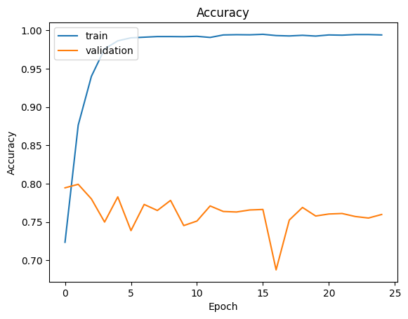

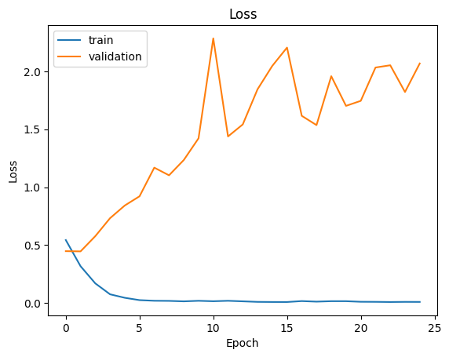

```python
plot_training_results(history_gru)
```

As you can see, our best validation accuracy was after the second epoch and it was 0.7991. This is not as good as the LSTM model so we can stick with the LSTM moving forward.

```python
del model
gc.collect()
```

```
120239
```

### Simple RNN

Lastly, we will look at a simple RNN model

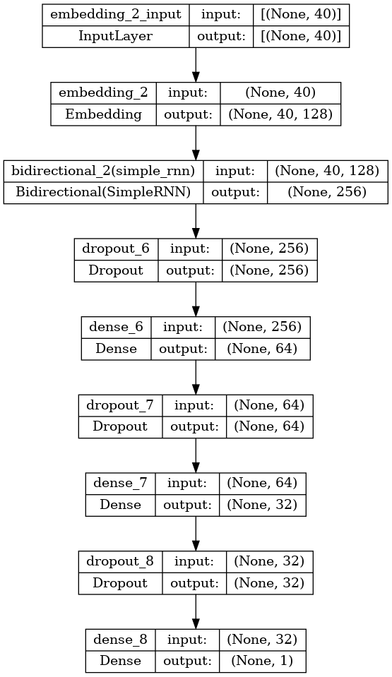

```python
model = make_rnn('SimpleRNN', 1)
keras.utils.plot_model(model, show_shapes=True)
```

```python
model.summary()
```

```
Model: "sequential_2"
_________________________________________________________________
 Layer (type)                Output Shape              Param #
=================================================================
 embedding_2 (Embedding)     (None, 40, 128)           2560000

 bidirectional_2 (Bidirectio  (None, 256)              65792
 nal)

 dropout_6 (Dropout)         (None, 256)               0

 dense_6 (Dense)             (None, 64)                16448

 dropout_7 (Dropout)         (None, 64)                0

 dense_7 (Dense)             (None, 32)                2080

 dropout_8 (Dropout)         (None, 32)                0

 dense_8 (Dense)             (None, 1)                 33

=================================================================
Total params: 2,644,353
Trainable params: 2,644,353
Non-trainable params: 0
_________________________________________________________________
```

Our Simple RNN model has the least amount of parameters, which makes sense given that it is simpler than both the LSTM and GRU models.

```python
epochs = 25

callbacks = [
    keras.callbacks.ModelCheckpoint("simple_rnn_{epoch}.tf"),
]
model.compile(
    optimizer=keras.optimizers.Adam(),
    loss="binary_crossentropy",
    metrics=["accuracy"],
)
history_simple_rnn = model.fit(
    x=sequences_train,
    y=train['target'],
    epochs=epochs,
    callbacks=callbacks,
    validation_data=(sequences_val, val['target']),
    batch_size=16
)
```

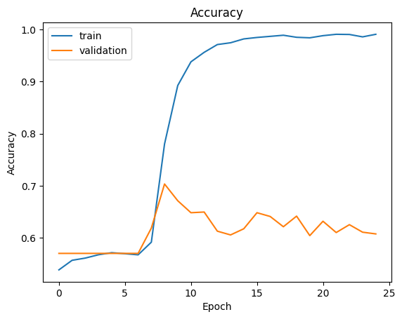

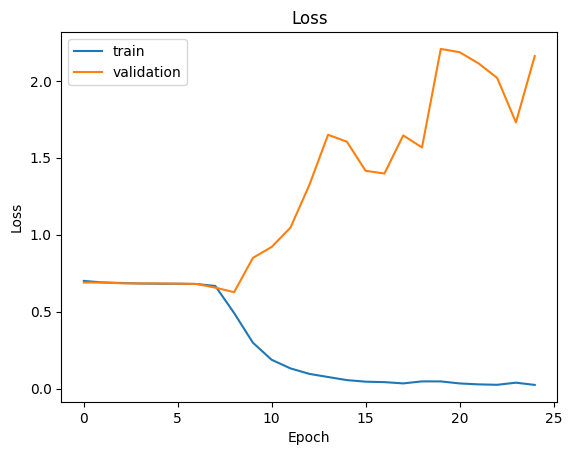

```python
plot_training_results(history_simple_rnn)
```

The best validation accuracy was after epoch 9 with a 0.7032. This is noticeably worse than the LSTM or GRU models, and we will now conduct some simple hyperparameter tuning with our LSTM model since it performed the best.

```python
del model
gc.collect()
```

```
61955
```

## Hyperparameter Tuning

It is clear from our experiments above that our best model is the LSTM model. This model achieved the best results out of the 3 experiments.

There are many different things that can be tuned to try and improve performance, but given the limited GPU resources that are available to me, I can not conduct a full scale hyperparameter tuning job. Instead, I will experiment with a lower and higher learning rate and see how that changes our results.

```python
model = make_rnn('LSTM', 1)

epochs = 25

callbacks = [
    keras.callbacks.ModelCheckpoint("lstm_lower_lr_{epoch}.tf"),
]
model.compile(
    optimizer=keras.optimizers.Adam(learning_rate=0.0001),
    loss="binary_crossentropy",
    metrics=["accuracy"],
)
history_lstm_lower_lr = model.fit(
    x=sequences_train,
    y=train['target'],
    epochs=epochs,
    callbacks=callbacks,
    validation_data=(sequences_val, val['target']),
    batch_size=16
)
```

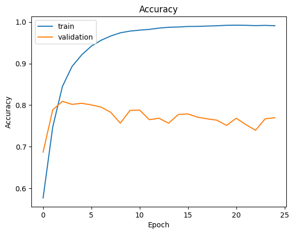

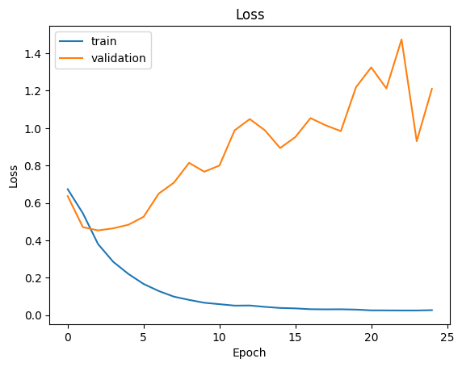

```python
plot_training_results(history_lstm_lower_lr)
```

As you can see, the lower learning rate does slightly improve the performance of our model. We now get a validation accuracy of 0.8089 after the third epoch. The lower learning rate also appears to cause the training to take slightly longer to converge, which makes sense.

```python
del model
gc.collect()
```

```
133632
```

```python
model = make_rnn('LSTM', 1)

epochs = 25

callbacks = [
    keras.callbacks.ModelCheckpoint("lstm_higher_lr_{epoch}.tf"),
]
model.compile(
    optimizer=keras.optimizers.Adam(learning_rate=0.01),
    loss="binary_crossentropy",
    metrics=["accuracy"],
)
history_lstm_higher_lr = model.fit(
    x=sequences_train,
    y=train['target'],
    epochs=epochs,
    callbacks=callbacks,
    validation_data=(sequences_val, val['target']),
    batch_size=16
)
```

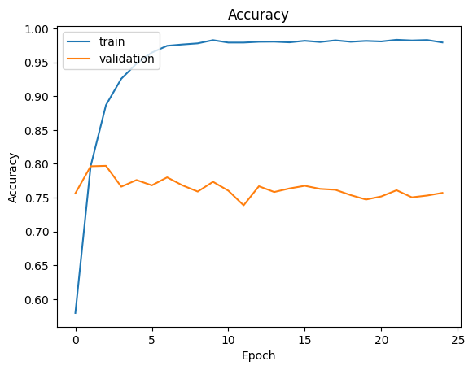

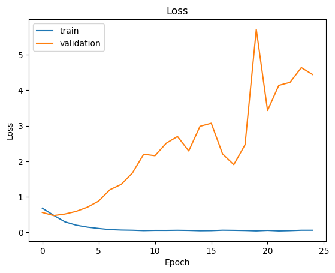

```python
plot_training_results(history_lstm_higher_lr)
```

Our higher learning rate model achieves a validation accuracy of 0.7971 after the third epoch.

## Results and Analysis

The following table summarizes the results from our experiments so far.

| Model | Validation Acc | Trainable Params |
| --- | --- | --- |
| LSTM | 0.8043 | 2,841,729 |
| GRU | 0.7991 | 2,776,705 |
| Simple RNN | 0.7032 | 2,644,353 |
| **LSTM with Lower LR** | 0.8089 | 2,841,729 |
| LSTM with Higher LR | 0.7971 | 2,841,729 |

It is clear that our LSTM with the lower learning rate is our best performing model. We will now take this best performing model and make predictions on the test dataset to submit to kaggle.

## Test Dataset

We will begin by loading in the best performing model

```python
best_model = make_rnn('LSTM', 1)
best_model.load_weights('/kaggle/working/lstm_lower_lr_3.tf')
```

```
<tensorflow.python.checkpoint.checkpoint.CheckpointLoadStatus at 0x7a4330bee4d0>
```

Next, we will load in the dataset and tokenize it the same we did with the train and val datasets.

```python
test_df = pd.read_csv("/kaggle/input/nlp-getting-started/test.csv")
```

```python
sequences = tokenizer.texts_to_sequences(test_df['text'])
sequences_test = keras.utils.pad_sequences(sequences, maxlen=40, padding='post')
```

Now we are ready to make predictions with our model

```python
predictions = best_model.predict(sequences_test)
```

```python
predictions
```

```
array([[0.69154036],
       [0.27224135],
       [0.91413987],
       ...,
       [0.868553  ],
       [0.93441343],
       [0.6263263 ]], dtype=float32)
```

We need to format our predictions to be 1s or 0s

```python
predictions = [1 if x >= 0.5 else 0 for x in predictions]
```

```python
submission = pd.DataFrame(test_df['id'])
```

```python
submission['target'] = predictions
```

```python
submission.head()
```

|  | id | target |
| --- | --- | --- |
| 0 | 0 | 1 |
| 1 | 2 | 0 |
| 2 | 3 | 1 |
| 3 | 9 | 0 |
| 4 | 11 | 1 |

```python
submission.to_csv('/kaggle/working/submission.csv', index=False)
```

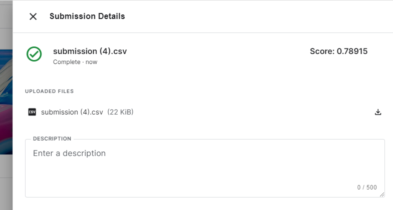

As you can see, we achieved a 0.78915 performance on Kaggle. This is pretty good, but I am sure that further improvements could get even better results!

## Conclusion

This competition was a great chance for me to learn about building recurrant neural networks from scratch. While my score is not at the top of the leaderboard, I now have a much better understanding of using Keras to build models from the ground up.

In my experiments, I found that LSTM cells performed the best with GRU close behind. This makes sense given the vast advantages to using LSTM or GRU as opposed to simple RNNs.

There are a handful of improvements that I would love to experiment with given the time. They can be seen below:

- Experiment with different loss functions and optimizers
- Experiment with a state of the art text classification model on tf.hub like BERT. In the past, I have used sentence bert models to create embeddings for whole sentences and then used an SVM on those embeddings to classify the sentences. This has yielded very good results for me on other projects and I am curious how that would perform here.
- Experiment with ensembling the predictions. I could take the LSTM and GRU models and ensemble them to potentially improve the model performance